# Tutorial on using Seaborn for Visualisation

### By Mahaprasad Mohanty [24MDT0061]

Seaborn is a Python visualization library based on matplotlib. It provides a high-level interface for drawing attractive statistical graphics.

# Installation

pip install seaborn

# Usecases and types of plots

### Before diving in, make sure you have the following libraries installed.

```python
import seaborn as sns
import matplotlib.pyplot as plt
import numpy as np
import pandas as pd
```

### 1. Scatterplot

#### When to use scatterplots?

- To examine relationship between 2 continous variables
- To identify correlations and patterns
- Detecting outliers

#### Common applications

- Stock price v/s trading volume relation
- Height v/s weight studies
- Temperature v/s energy consumption studies, etc

#### Key Parameters used

- x, y: Variables that specify the coordinates
- hue: Variable for color encoding
- size: Variable for size encoding
- style: Variable for shape encoding
- data: Input dataset (DataFrame)

### Example

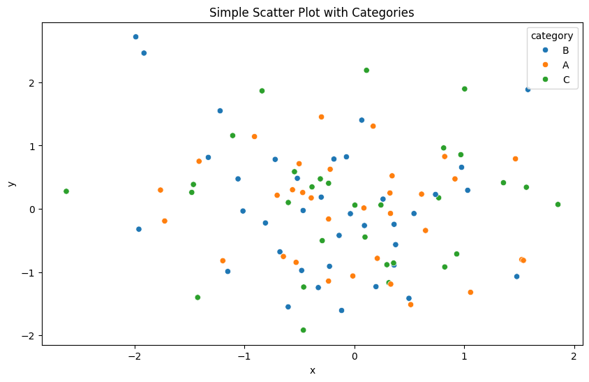

```python
np.random.seed(42)
n_points = 100
data = pd.DataFrame({
    'x': np.random.normal(0, 1, n_points),
    'y': np.random.normal(0, 1, n_points),
    'category': np.random.choice(['A', 'B', 'C'], n_points)
})
plt.figure(figsize=(10, 6))
sns.scatterplot(data=data, x='x', y='y', hue='category')
plt.title('Simple Scatter Plot with Categories')
plt.show()
```

### 2. Lineplot

#### When to use lineplots?

- Showing trends over time
- Comparing multiple time series
- Visualizing continuous relationships

#### Common Applications

- Time series data
- Sequential numerical data
- Multiple series with a common x-axis

#### Key Parameters used

- x, y: Variables for the line coordinates
- hue: Grouping variable for multiple lines
- orient: “x” or “y”
- estimator: Method for aggregating multiple y values at same x value

### Example

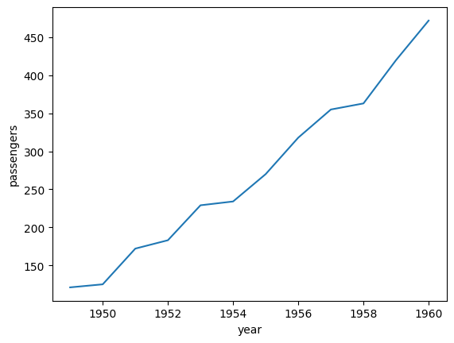

```python
flights = sns.load_dataset("flights")
flights.head()

# using long form data
may_flights = flights.query("month == 'May'")
sns.lineplot(data=may_flights, x="year", y="passengers")
```

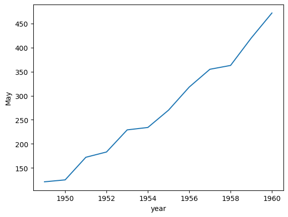

```python
# for wide-form representation
flights_wide = flights.pivot(index="year", columns="month", values="passengers")
flights_wide.head()

# plotting a single vector and passing it to data
sns.lineplot(data=flights_wide["May"])
```

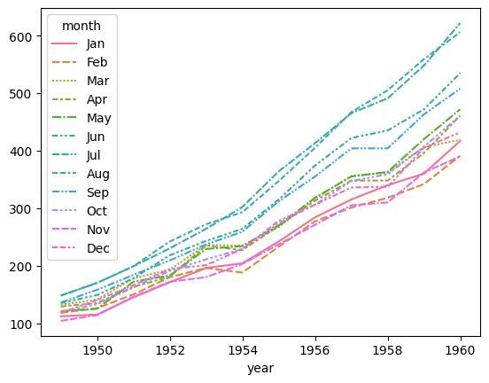

```python
# passing the entire wide-form dataset

sns.lineplot(data=flights_wide)
```

### 3. Histplot

#### When to use?

- to understand distribution of single variable
- checking for normality
- Identify the modes and skewness

#### Common Applications

- Age distributions
- Income distributions
- Response times

#### Key parameters used

- data: Input array or variable
- bins: Number of bins or bin edges
- kde: Whether to overlay a kernel density estimate
- stat: Statistic to compute ('count', 'frequency', 'density', 'probability')

## Example

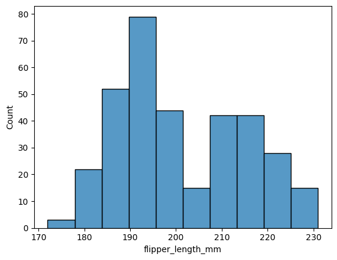

```python
penguins = sns.load_dataset("penguins")
sns.histplot(data=penguins, x="flipper_length_mm")
```

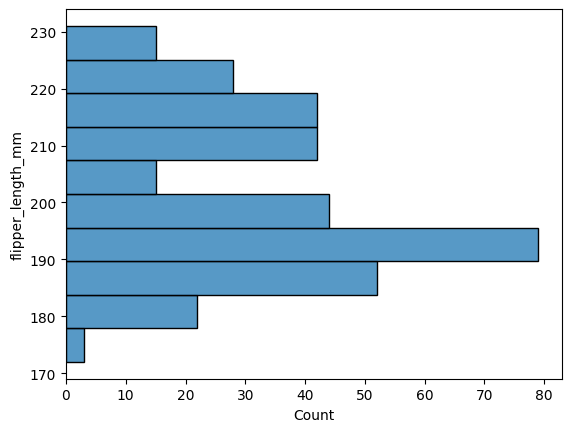

```python
# plotting on the y axis
sns.histplot(data=penguins, y="flipper_length_mm")
```

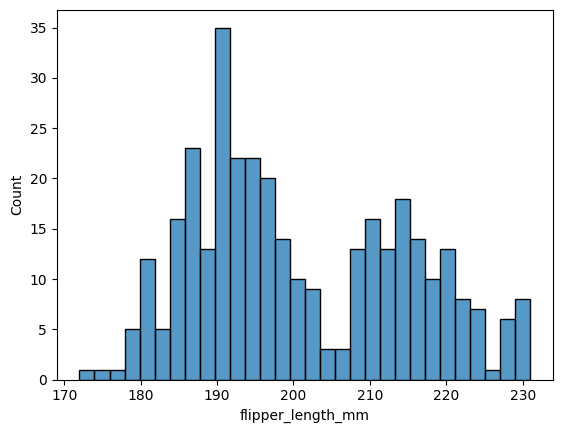

```python
# modifying the bin width
sns.histplot(data=penguins, x="flipper_length_mm", bins=30)
```

### 4. Boxplots

#### When to use

- Comparing distributions across categories
- Identifying outliers
- Showing summary statistics (median, quartiles)

#### Common Applications

- Salary distributions by department
- Product measurements by batch
- Student performance by class

#### Key Parameters used

- x: Categorical variable
- y: Continuous variable
- hue: Additional categorical variable for nested boxplots
- whis: Whisker length as a multiple of the IQR
- orient: Orientation of the plot (“v” | “h” | “x” | “y”)

### Examples

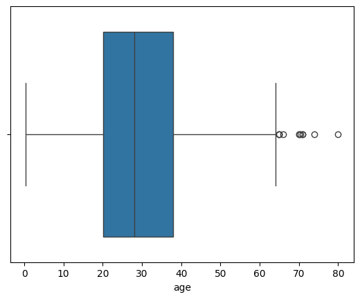

```python
titanic = sns.load_dataset("titanic")
sns.boxplot(x=titanic["age"])
```

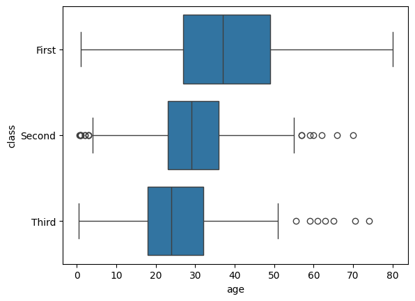

```python
# Group by a categorical variable, referencing columns
sns.boxplot(data=titanic, x="age", y="class")
```

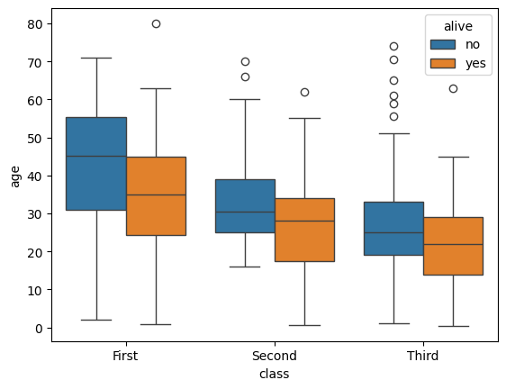

```python
# vertical boxplot with nested grouping
sns.boxplot(data=titanic, x="class", y="age", hue="alive")
```

### 5. Heatmaps

#### When to use?

- Visualizing correlation matrices
- Displaying confusion matrices
- Showing complex relationships between multiple variables

#### Common Applications

- Feature correlation in machine learning
- Customer behavior patterns
- Performance metrics across time periods

#### Key Parameters used

- data: 2D dataset that can be coerced into a DataFrame
- annot: If True, writes values inside cells
- cmap: Color map for the heatmap
- center: Value at which to center the colormap
- vmin, vmax: Values to anchor the colormap

### Examples

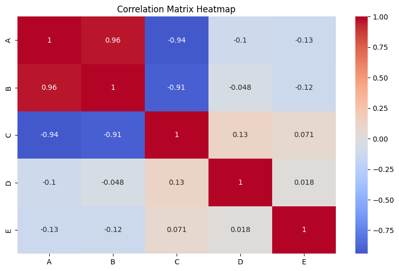

```python
# Generate correlated data
np.random.seed(42)
data = pd.DataFrame(np.random.randn(100, 5), columns=['A', 'B', 'C', 'D', 'E'])
data['B'] = data['A'] + np.random.randn(100) * 0.3
data['C'] = -data['A'] + np.random.randn(100) * 0.3

correlation = data.corr()

plt.figure(figsize=(10, 6))
sns.heatmap(correlation, annot=True, cmap='coolwarm', center=0)
plt.title('Correlation Matrix Heatmap')
plt.show()
```

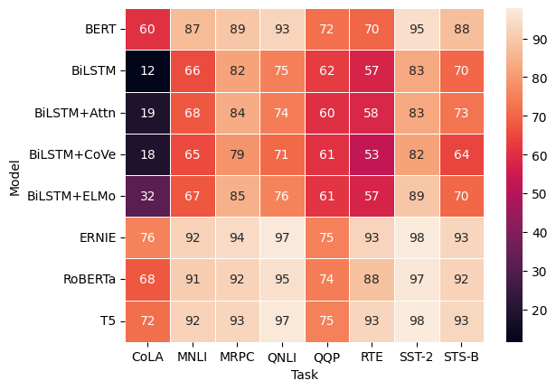

```python
glue = sns.load_dataset("glue").pivot(index="Model", columns="Task", values="Score")

# adding lines between cells
sns.heatmap(glue, annot=True, linewidth=.5)
```

### 6. KDE Plots

#### When to use?

- Visualizing continuous probability distributions
- Comparing smooth distributions
- Identifying modes and skewness

#### Common Applications

- Population density analysis
- Probability distribution modeling
- Signal processing visualization

#### Key Parameters used

- data: Input data
- bw_adjust: Factor to scale the bandwidth
- fill: If True, fills the space under the curve
- cumulative: If True, plots the cumulative distribution
- palette: Method for choosing the colors
- hue_order: pecify the order of processing and plotting for categorical levels

### Examples

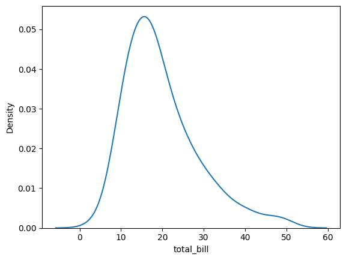

```python
# a univariate distribution along the x axis
tips = sns.load_dataset("tips")
sns.kdeplot(data=tips, x="total_bill");
```

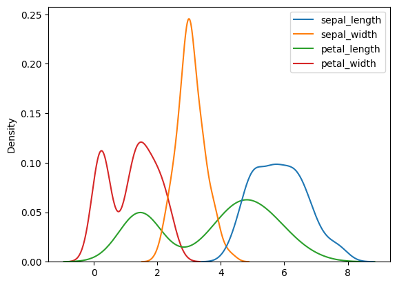

```python
# distributions for each column of a wide-form datase
iris = sns.load_dataset("iris")
sns.kdeplot(data=iris);
```

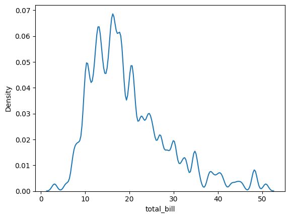

```python
# using less smoothing
sns.kdeplot(data=tips, x="total_bill", bw_adjust=.2)
```

### 7. Pairplot

#### When to use?

- Exploring relationships between multiple variables
- Initial data exploration
- Finding correlations in multivariate data

#### Common Applications

- Exploratory Data Analysis (EDA)
- Feature selection for machine learning
- Scientific measurement correlations

#### Key Parameters used

- data: DataFrame with variables to plot
- hue: Variable for color encoding
- diag_kind: Kind of plot for diagonal ('hist', 'kde')
- plot_kws: Additional plotting keywords
- pallete: Set of colors for mapping the hue variable.

### Examples

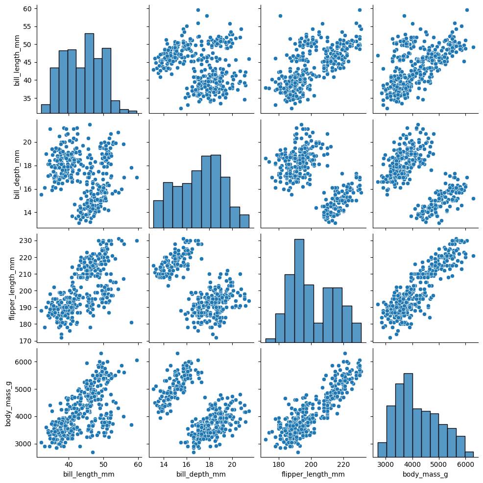

```python
penguins = sns.load_dataset("penguins")
sns.pairplot(penguins);
```

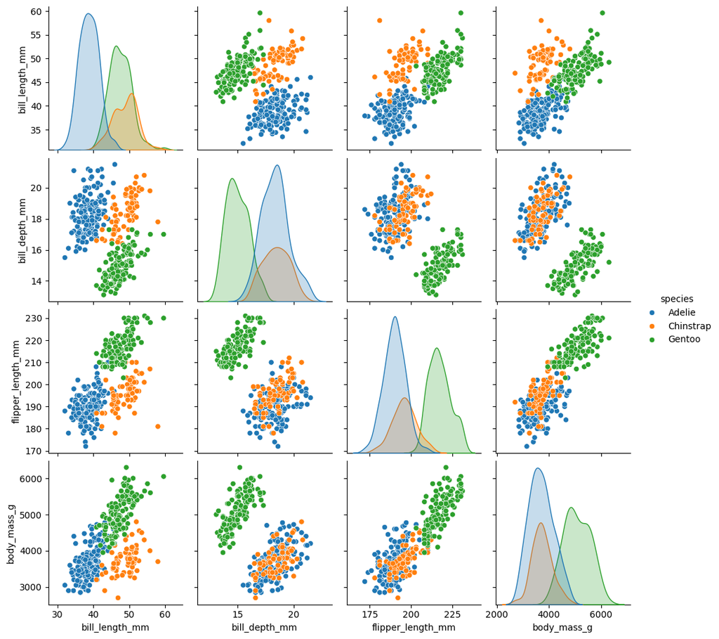

```python
# Assigning a hue variable adds a semantic mapping and changes the default marginal plot to a layered kernel density estimate
sns.pairplot(penguins, hue="species");
```

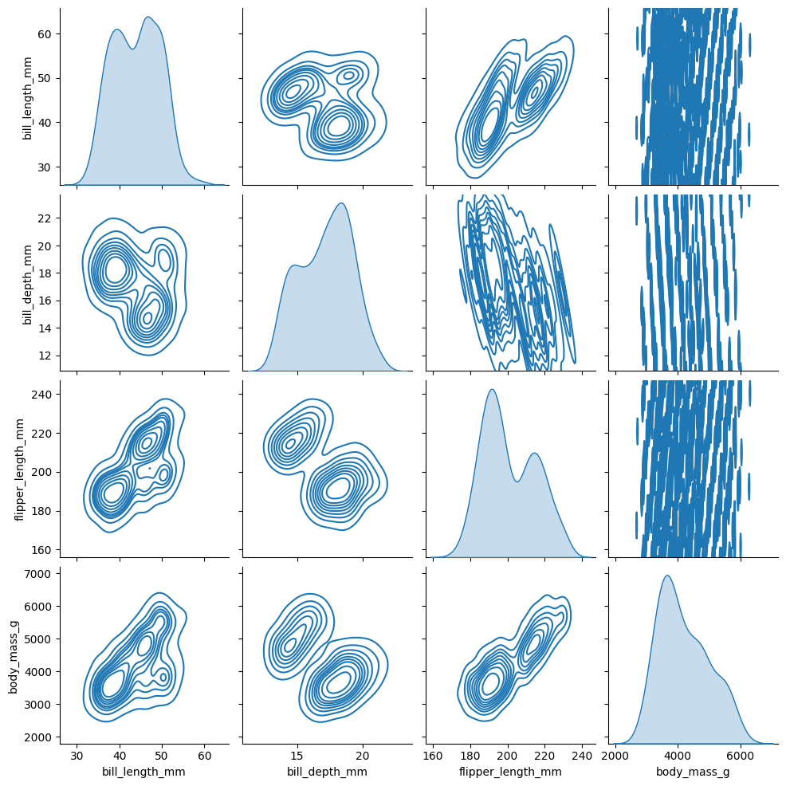

```python
# The kind parameter determines both the diagonal and off-diagonal plotting style
sns.pairplot(penguins, kind="kde")
```

### 8. Violin plots

#### When to use?

- Comparing distributions across multiple categories
- Identifying multimodal distributions (multiple peaks)
- Showing the full shape of data distribution

#### Common applications

- Violin plots can be used to compare the peaks, valleys.
- can show the presence of different peaks, their position
- can visualize the entire distribution of the data, including the tails, which might not be visible in a box plot.

#### Key parameters

- data:DataFrame containing the data
- x : Category variable or vector data
- y: Value variable or vector data
- hue: Variable for splitting violins
- order: Order of categorical variables
- scale: The method used to scale the width

### Examples

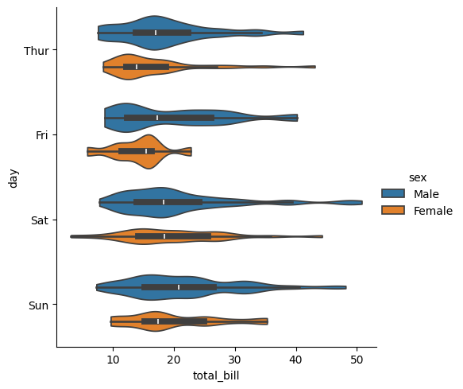

```python
sns.catplot(
    data=tips, x="total_bill", y="day", hue="sex",
    kind="violin", bw_adjust=.5, cut=0,
);
```

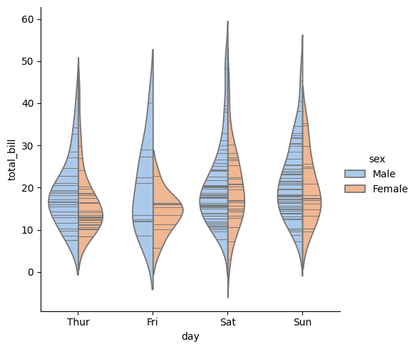

```python
# modifying the interior
sns.catplot(
    data=tips, x="day", y="total_bill", hue="sex",
    kind="violin", inner="stick", split=True, palette="pastel",
)
```

And with this I conclude this report. We have explored various important functions used in seaborn for data visualisation.

Thank you.